# Public Investment Risk Analysis in the Dominican Republic

Gari Jerez

2026-03-28

## 1. Introduction

This project analyzes public investment projects using data from the Ministry of Economy, Planning and Development (MEPyD).  
The objective is to evaluate project performance using financial indicators such as Net Present Value (NPV), sector investment trends, and risk simulation using Monte Carlo methods.

# 2. Libraries

# 3. Load Data

# 4. Data Cleaning

| IdProyecto | Proyecto | Sector | Provincia | Año | Flujo (RD$) |
| --- | --- | --- | --- | --- | --- |
| 10 | MEJORAMIENTO DE LA SANIDAD E INOCUIDAD AGROALIMENTARIA EN LA REPUBLICA DOMINICANA (PATCA III) | Agropecuaria caza pesca y silvicultura | DISTRITO NACIONAL | 2016 | 23064672.48 |
| 10 | MEJORAMIENTO DE LA SANIDAD E INOCUIDAD AGROALIMENTARIA EN LA REPUBLICA DOMINICANA (PATCA III) | Agropecuaria caza pesca y silvicultura | DISTRITO NACIONAL | 2017 | 96114402.64999999 |
| 10 | MEJORAMIENTO DE LA SANIDAD E INOCUIDAD AGROALIMENTARIA EN LA REPUBLICA DOMINICANA (PATCA III) | Agropecuaria caza pesca y silvicultura | DISTRITO NACIONAL | 2018 | 87935232.32 |
| 10 | MEJORAMIENTO DE LA SANIDAD E INOCUIDAD AGROALIMENTARIA EN LA REPUBLICA DOMINICANA (PATCA III) | Agropecuaria caza pesca y silvicultura | DISTRITO NACIONAL | 2019 | 0 |
| 1030 | AMPLIACIÓN ACUEDUCTO JORGILLO COMO EXTENSION ACUEDUCTO DEL CERCADO PROVINCIA SAN JUAN | Vivienda y servicios comunitarios | SAN JUAN | 2017 | 33978219.57 |
| 1030 | AMPLIACIÓN ACUEDUCTO JORGILLO COMO EXTENSION ACUEDUCTO DEL CERCADO PROVINCIA SAN JUAN | Vivienda y servicios comunitarios | SAN JUAN | 2018 | 21435937.26 |
| 1030 | AMPLIACIÓN ACUEDUCTO JORGILLO COMO EXTENSION ACUEDUCTO DEL CERCADO PROVINCIA SAN JUAN | Vivienda y servicios comunitarios | SAN JUAN | 2019 | 81348617.52 |
| 1030 | AMPLIACIÓN ACUEDUCTO JORGILLO COMO EXTENSION ACUEDUCTO DEL CERCADO PROVINCIA SAN JUAN | Vivienda y servicios comunitarios | SAN JUAN | 2021 | 0 |
| 1042 | AMPLIACIÓN ACUEDUCTO LINEA NOROESTE PROVINCIA MONTE CRISTI | Vivienda y servicios comunitarios | MONTE CRISTI | 2016 | 1112575.78 |
| 1042 | AMPLIACIÓN ACUEDUCTO LINEA NOROESTE PROVINCIA MONTE CRISTI | Vivienda y servicios comunitarios | MONTE CRISTI | 2017 | 5171156.5 |

[output cut: 10 more lines]

# 5. Net Present Value Calculation

The Net Present Value (NPV) of each project is calculated using a discount rate of 12%.  
The indicator measures the economic profitability of each investment project by discounting future execution flows to their present value.

|  | sector | n_proyectos | vpn_prom | vpn_total | duracion_prom |
| --- | --- | --- | --- | --- | --- |
| 1 | Actividades deportivas recreativas culturales y religiosas | 263 | -44231609.99515399 | -11632913428.7255 | 2.802281368821293 |
| 2 | Administración general | 52 | -120920758.4359431 | -6287879438.669044 | 3.673076923076923 |
| 3 | Agropecuaria caza pesca y silvicultura | 25 | -100001373.2380519 | -2500034330.951298 | 4.6 |
| 4 | Asuntos económicos comerciales y laborales | 3 | 4878819.585729405 | 14636458.75718822 | 4 |
| 5 | Cambio Climático | 160 | -126442067.8890644 | -20230730862.25031 | 1.925 |
| 6 | Comunicaciones | 1 | 24697926143.87169 | 24697926143.87169 | 4 |
| 7 | Defensa nacional | 12 | 1050852379.476906 | 12610228553.72287 | 1.916666666666667 |
| 8 | Educación | 1208 | 115741499.7683176 | 139815731720.1276 | 3.741721854304636 |
| 9 | Energia y combustible | 14 | -9676330756.52057 | -135468630591.288 | 3 |
| 10 | Justicia orden público y seguridad | 42 | 31248242000.76359 | 1312426164032.071 | 4.285714285714286 |

[output cut: 9 more lines]

## Net Present Value by Sector

The following table summarizes the average and total NPV by sector.

| Sector | Projects | Avg NPV (RD$) | Total NPV (RD$) | Avg Duration |
| --- | --- | --- | --- | --- |
| Justicia orden público y seguridad | 42 | 31,248,242,001 | 1,312,426,164,032 | 4.29 |
| Protección de la biodiversidad y ordenación de desechos | 28 | 9,826,378,550 | 275,138,599,409 | 3.18 |
| Educación | 1208 | 115,741,500 | 139,815,731,720 | 3.74 |
| Protección social | 22 | 3,414,197,843 | 75,112,352,537 | 4.45 |
| Vivienda y servicios comunitarios | 477 | 110,838,019 | 52,869,735,155 | 3.23 |
| Comunicaciones | 1 | 24,697,926,144 | 24,697,926,144 | 4 |
| Defensa nacional | 12 | 1,050,852,379 | 12,610,228,554 | 1.92 |
| Riego | 33 | 156,089,502 | 5,150,953,557 | 4.03 |
| Asuntos económicos comerciales y laborales | 3 | 4,878,820 | 14,636,459 | 4 |
| Mineria manufactura y construccion | 3 | -58,064,851 | -174,194,554 | 5.67 |

[output cut: 9 more lines]

## Distribution of Net Present Value

To understand the variability in project profitability, the distribution of NPV values is visualized below.

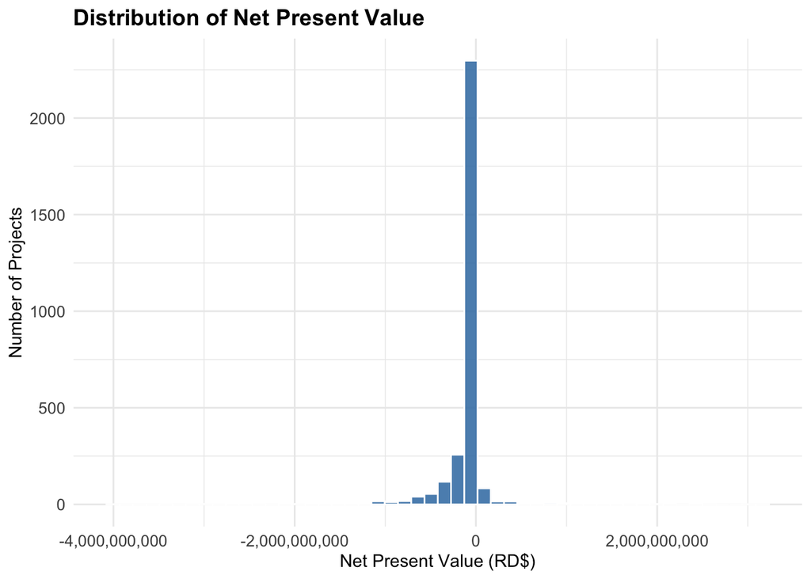

Figure 5.1 Distribution of Net Present Value across Projects

## Top Projects by Net Present Value

The following table lists the ten projects with the highest net present value.

| Project | Sector | Duration | NPV (RD$) |
| --- | --- | --- | --- |
| HUMANIZACION DEL SISTEMA PENITENCIARIO DE LA REPÚBLICA DOMINICANA | Justicia orden público y seguridad | 8 | 1,323,082,661,344 |
| RECUPERACIÓN DE LA COBERTURA VEGETAL EN CUENCAS HIDROGRÁFICAS DE LA REPÚBLICA DOMINICANA. | Protección de la biodiversidad y ordenación de desechos | 9 | 181,013,024,276 |
| MEJORAMIENTO DE 100 000 VIVIENDAS EN LA REPÚBLICA DOMINICANA | Vivienda y servicios comunitarios | 3 | 114,196,838,487 |
| CONSTRUCCIÓN DE PLANTELES EDUCATIVOS EN LA PROVINCIA DE SANTO DOMINGO (FASE 2) | Educación | 10 | 66,477,257,739 |
| MEJORAMIENTO Y NORMALIZACIÓN DE SITIOS DE DISPOSICIÓN FINAL DE RESIDUOS SÓLIDOS EN LA REPÚBLICA DOMINICANA | Protección de la biodiversidad y ordenación de desechos | 2 | 65,391,506,383 |
| APOYO A LA PROTECCION Y PROMOCION SOCIAL (PROSOLI) | Protección social | 7 | 57,667,440,526 |
| REHABILITACIÓN DE 40 KM DE VÍAS TERCIARIAS CONEXAS A LA CARRETERA GREGORIO LUPERÓN PROVINCIAS SANTIAGO Y PUERTO PLATA | Transporte | 2 | 32,767,053,474 |
| CONSTRUCCIÓN DE 78 PLANTELES ESCOLARES EN LA PROVINCIA SANTO DOMINGO | Educación | 9 | 31,885,771,558 |
| MEJORAMIENTO DE LA CONECTIVIDAD PARA LA TRANSFORMACION DIGITAL EN LA REPUBLICA DOMINICANA | Comunicaciones | 4 | 24,697,926,144 |
| FORTALECIMIENTO DE LAS CAPACIDADES PARA LA GESTIÓN INTEGRAL DE LOS RESIDUOS SÓLIDOS EN LA REP. DOM. | Protección de la biodiversidad y ordenación de desechos | 4 | 20,881,555,256 |

# 6. Relationship Between Duration and NPV

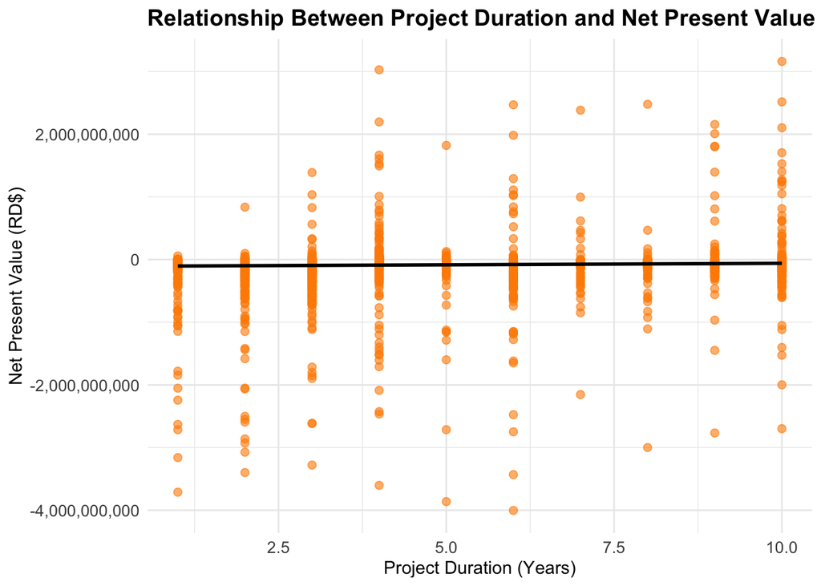

Figure 6. Relationship Between Project Duration and Net Present Value

# 7. Sector Investment Analysis

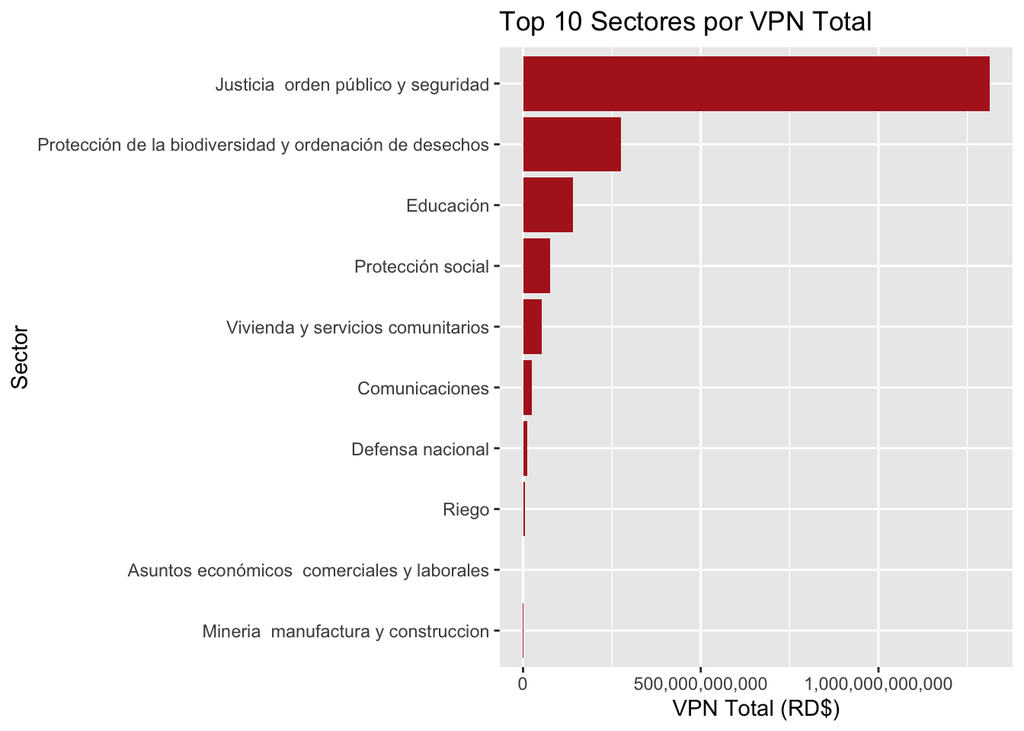

Figure 3. Top Sectors by Total Net Present Value of Public Investment Projects

# 8. Investment Trends Over Time

[figure not shown]

Figure 8. Evolution of Public Investment by Sector Over Time

# 9. Geospatial Investment Analysis

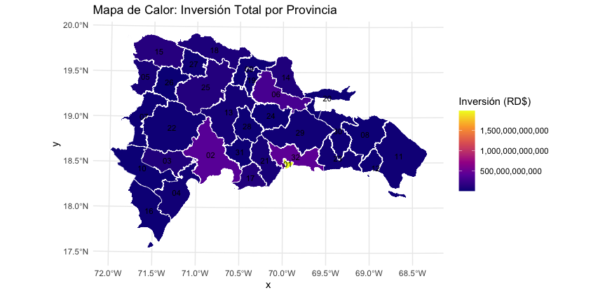

Figure 9. Geographic Distribution of Public Investment by Province

# 10. Monte Carlo Simulation

Monte Carlo simulation is used to evaluate project risk.

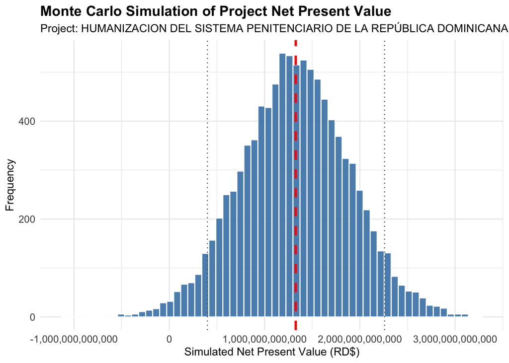

Figure 10. Monte Carlo Simulation of Net Present Value for the Selected Project

# 11. Cumulative Distribution Function

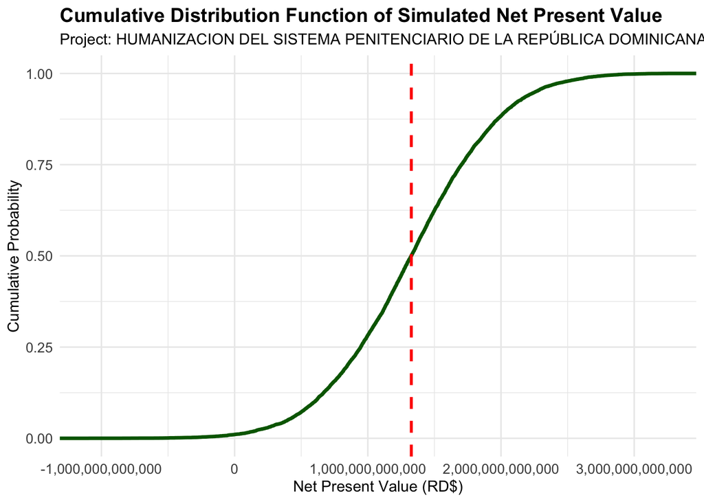

Figure 11. Cumulative Distribution Function of Simulated Net Present Value

# 12. Conclusion

The analysis reveals substantial heterogeneity in the performance of public investment projects across sectors and regions. The Net Present Value (NPV) results indicate that while some sectors generate consistently positive returns, others exhibit lower profitability and higher dispersion.

The distribution and relationship analysis suggest that project duration does not guarantee higher returns, highlighting the importance of efficient resource allocation and project management.

From a risk perspective, the Monte Carlo simulation provides critical insights into the uncertainty surrounding project outcomes. The results show not only the expected range of returns but also the probability of negative NPV, offering a more comprehensive framework for decision-making under uncertainty.

Overall, this analysis demonstrates the value of combining financial evaluation techniques with statistical and geospatial methods to support evidence-based public investment decisions.

Future work could extend this approach by incorporating macroeconomic variables, sector-specific risk factors, and machine learning models to improve predictive accuracy.